# Assignment 1 Markdown

## 9

*Microsoft program security issues.* The dominance of Microsoft in the computer software market has led to numerous malicious attacks (e.g., worms, viruses) on its programs. To help its users combat these problems, Microsoft periodically issues a Security Bulletin that reports the software affected by the vulnerability. In Computers & Security (July 2013), researchers focused on reported security issues with three Microsoft products: Office, Windows, and Explorer. In a sample of 50 security bulletins issued in 2012, 32 reported a security issue with Windows, 6 with Explorer, and 12 with Office. The researchers also categorized the security bulletins according to the expected repercussion of the vulnerability. Categories were Denial of service, Information disclosure, Remote code execution, Spoofing, and Privilege elevation. Suppose that of the 50 bulletins sampled, the following numbers of bulletins were classified into each respective category: 6, 8, 22, 3, 11.

1. Construct a pie chart to describe the Microsoft products with security issues. Which product had the lowest proportion of security issues in 2012?

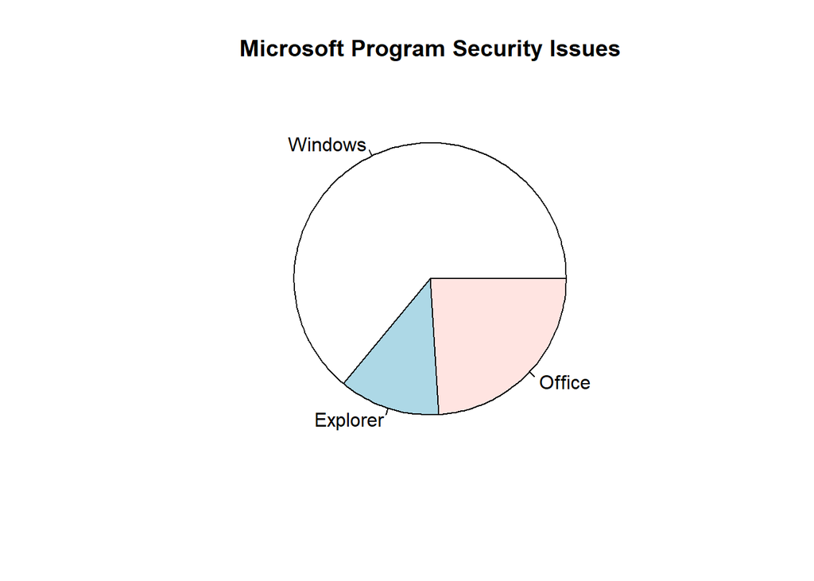

```r
reports <- c(32,6,12)
products <- c("Windows", "Explorer", "Office")
pie(reports, labels=products, main = "Microsoft Program Security Issues")
```

In 2012, Explorer had the lowest proportion of security issues.

2. Construct a Pareto diagram to describe the expected repercussions from security issues. Based on the graph, what repercussion would you advise Microsoft to focus on?

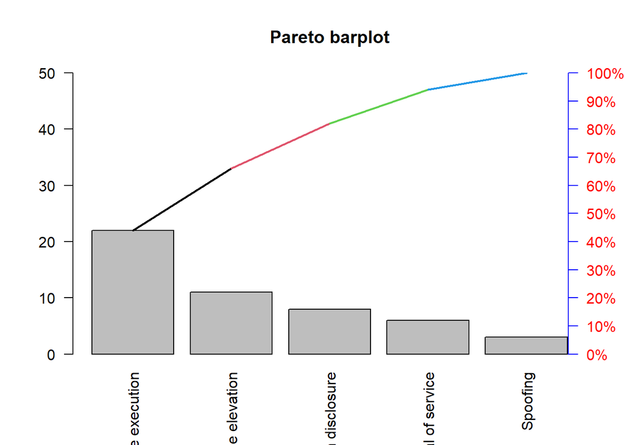

```r
freq=c(6, 8, 22, 3, 11)
RL=c("Denial of service", "Information disclosure", "Remote code execution", "Spoofing", "Privilege elevation")
l=rep(RL,freq)
pareto(l)
```

Microsoft should probably focus on remote code execution (as it is the most frequent here and generally not a good thing…)